# Item Response Theory

# Item Response Theory

- What do you do if you have dichotomous (or categorical) manifest variables?
  - Many agree that more than four response options can be treated as continuous without a loss in power or interpretation.
  - Do you treat these values as categorical?
- Do you assume the underlying latent variable is continuous?

# Categorical Options

- There are two approaches that allow us to analyze data with categorical predictors:
  - Item Factor Analysis
    - More traditional factor analysis approach using ordered responses
    - You can talk about item loading, eliminate bad questions, etc.
    - In the `lavaan` framework, you update your `cfa()` to include the `ordered` argument
  - Item Response Theory

# Item Response Theory

- Classical test theory is considered “true score theory”
  - Any differences in responses are differences in ability or underlying trait
  - CTT focuses on reliability and item correlation type analysis
  - Cannot separate the test and person characteristics
- IRT is considered more modern test theory focusing on the latent trait
  - Focuses on the item for *where* it measures a latent trait, discrimination, and guessing
  - Additionally, with more than two outcomes, we can examine ordering, response choice options, and more

# Issues

- Unidimensionality: assumption is that there is one underlying trait or dimension you are measuring
  - You can run separate models for each dimension
  - There are multitrait options for IRT
- Local Independence
  - After you control for the latent variable, the items are uncorrelated

# Item Response Theory

- A simple example of test versus person
  - 3 item questionnaire
  - Yes/no scaling
  - 8 response patterns
  - Four total scores (0, 1, 2, 3)

# Item Response Theory

- Item characteristic curves (ICCs)
  - The log probability curve of theta and the probability of a correct response

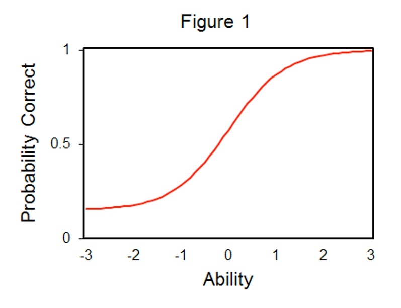

# Item Response Theory

- Theta – ability or the underlying latent variable score
- b – Item location – where the probability of getting an item correct is 50/50
  - Also considered where the item performs best
  - Can be thought of as item difficulty

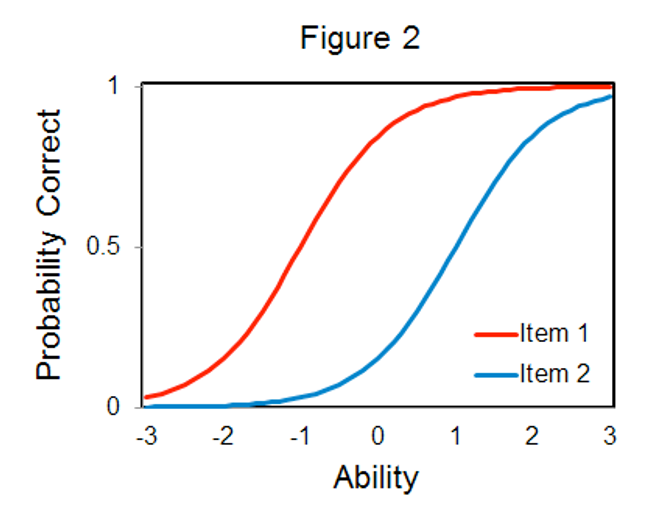

# Item Response Theory

- a – item discrimination
  - Tells you how well an item measures the latent variable
  - Larger a values indicate better items

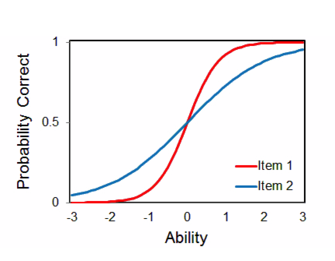

# Item Response Theory

- c – guessing parameter
  - The lower level likelihood of getting the item correct

[figure not shown]

# Item Response Theory

- 1 Parameter Logistic (1PL)
  - Also known as the Rasch Model
  - Only uses b
- 2 Parameter Logistic (2PL)
  - Uses b and a
- 3 Parameter Logistic (3PL)
  - Uses b, a, and c

# Polytomous IRT

- A large portion of IRT focuses on dichotomous data (yes/no, correct/incorrect)
- Scoring is easier because you have “right” and “wrong” answers
- Separately, polytomous IRT focuses on data with multiple answers, with no “right” answer
  - Focus on ordering, meaning that low scores represent lower abilities, while high scores are higher abilities
  - Likert type scales

# Polytomous IRT

- Couple of types of models:
  - Graded Response Model
  - Generalized Partial Credit Model
  - Partial Credit Model

# Polytomous IRT

- A graded response model is simplest but can be hard to fit.
- Takes the number of categories – 1 and creates mini 2PLs for each of those boundary points (1-rest, 2-rest, 3-rest, etc.).
- You get probabilities of scoring at this level OR higher

# Polytomous IRT

- The generalized partial credit and partial credit models account for the fact that you may not have each category used equally
- Therefore, you get the mini 2PLs for adjacent categories (1-2, 2-3, 3-4)
- If your categories are ordered (which you often want), these two estimations can be very similar.
- Another concern with the partial credit models is making sure that all categories have a point at which they are the most likely answer (thresholds)

# Polytomous IRT

- Install the `mirt()` library to use the multidimensional IRT package.
- We are not covering multiple dimensional or multigroup IRT, but this package can do those models or polytomous estimation.

# IRT Examples

- Let’s start with DIRT: Dichotomous IRT
- Dataset is the LSAT, which is scored as right or wrong

```r
library(ltm)
library(mirt)
data(LSAT)
head(LSAT)
```

```
#>   Item 1 Item 2 Item 3 Item 4 Item 5
#> 1      0      0      0      0      0
#> 2      0      0      0      0      0
#> 3      0      0      0      0      0
#> 4      0      0      0      0      1
#> 5      0      0      0      0      1
#> 6      0      0      0      0      1
```

# Two Parameter Logistic

```r
# Data frame name ~ z1 for one latent variable
#irt.param to give it to you standardized
LSAT.model <- ltm(LSAT ~ z1,
                  IRT.param = TRUE)
```

# 2PL Output

- Difficulty = b = theta = ability
- Discrimination = a = how good the question is at figuring a person out.

```r
coef(LSAT.model)
```

```
#>            Dffclt    Dscrmn
#> Item 1 -3.3597341 0.8253715
#> Item 2 -1.3696497 0.7229499
#> Item 3 -0.2798983 0.8904748
#> Item 4 -1.8659189 0.6885502
#> Item 5 -3.1235725 0.6574516
```

# 2PL Plots

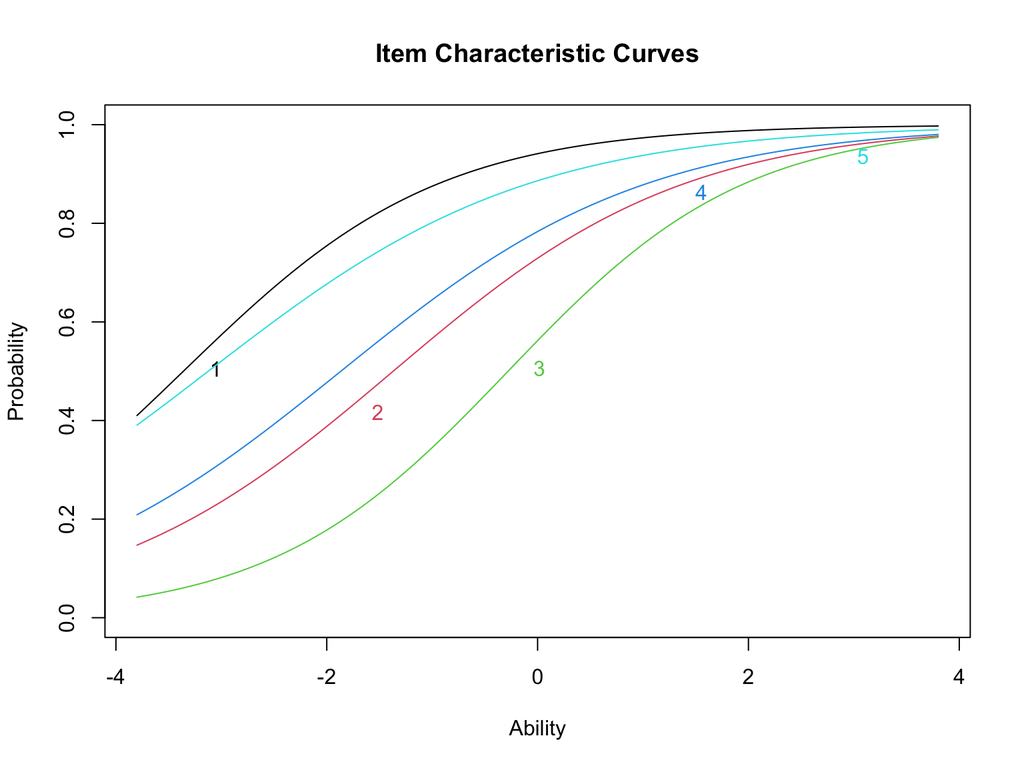

```r
plot(LSAT.model, type = "ICC") ## all items at once
```

# 2PL Plots

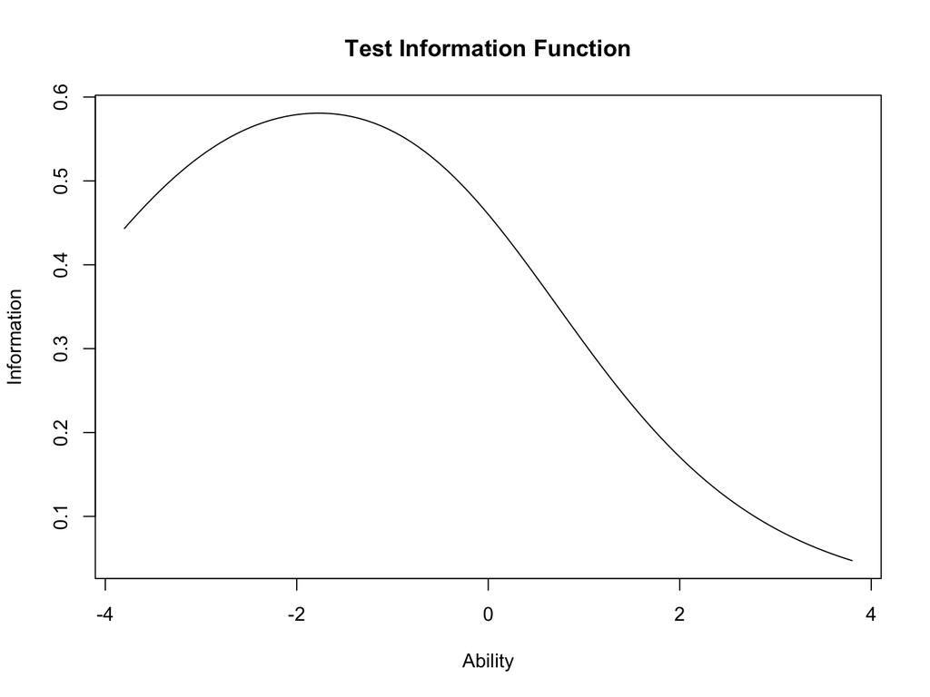

```r
plot(LSAT.model, type = "IIC", items = 0) ## Test Information Function
```

# 2PL Other Options

```r
factor.scores(LSAT.model)
```

```
#>
#> Call:
#> ltm(formula = LSAT ~ z1, IRT.param = TRUE)
#>
#> Scoring Method: Empirical Bayes
#>
#> Factor-Scores for observed response patterns:
#>    Item 1 Item 2 Item 3 Item 4 Item 5 Obs     Exp     z1
#> 1       0      0      0      0      0   3   2.277 -1.895
#> 2       0      0      0      0      1   6   5.861 -1.479
#> 3       0      0      0      1      0   2   2.596 -1.460
#> 4       0      0      0      1      1  11   8.942 -1.041
#> 5       0      0      1      0      0   1   0.696 -1.331
#> 6       0      0      1      0      1   1   2.614 -0.911
#> 7       0      0      1      1      0   3   1.179 -0.891
```

[output cut: 54 more lines]

# Three Parameter Logistic

```r
LSAT.model2 <- tpm(LSAT, #dataset
                   type = "latent.trait",
                   IRT.param = TRUE)
```

# 3PL Output

- Difficulty = b = theta = ability
- Discrimination = a = how good the question is at figuring a person out.
- Guessing = c = how easy the item is to guess

```r
coef(LSAT.model2)
```

```
#>            Gussng     Dffclt     Dscrmn
#> Item 1 0.06389395 -3.3423509  0.8048523
#> Item 2 0.01567005 -1.5530954  0.6070241
#> Item 3 0.30088256  0.3301527 26.4150208
#> Item 4 0.06521055 -2.0342571  0.5700252
#> Item 5 0.02908352 -3.5826451  0.5523586
```

# 3PL Plots

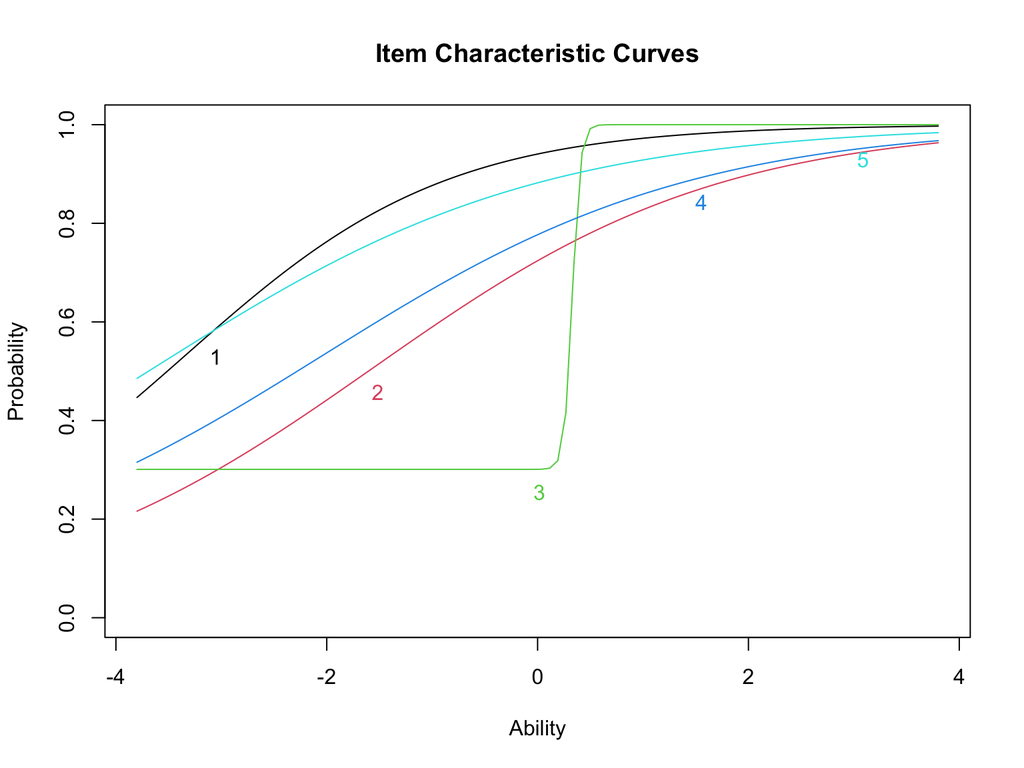

```r
plot(LSAT.model2, type = "ICC") ## all items at once
```